# Using Particle Swarm Optimization Algorithms for Finding E-optimal Design of Heteroscedastic Polynomial Model

Ping-Yang Chen

2025-12-08

# Theoretical Foundation

We revisit Dette (1993), where he found selected $E$-optimal designs for polynomial models with response $y$ and its expectation, $E(y)$, is modeled as a polynomial regression model using a single explanatory factor with $M$ monomials, $p_1, p_2, \ldots, p_M$, i.e.
$$\begin{equation}
E(y) = \eta(x, \boldsymbol\theta) = \theta_0 + \sum_{m = 1}^M \theta_m
x^{p_m},~x\in[a, b],~\boldsymbol\theta = (\theta_0, \theta_1, \ldots,
\theta_M).
\end{equation}$$
The simplest case is obtained when $(p_1, p_2, \ldots, p_M) = (1, 2, \ldots, M)$, and the regression function becomes a polynomial of degree $M$.

# Implementation

## Dependency

```r
install.packages("globpso")
install.packages("Rcpp")
install.packages("RcppArmadillo")
```

## `genHeterPolyE`: The Main Function

[output not shown]

# Examples

```r
# Import the main function
source("Approx_HeterPoly.R")
```

## Case 1

```r
# Set the design requirements
n <- 2                # the number of support points
dSpace <- c(-1, 1)    # the design space, c(lower, upper)
pOrder <- c(0, 1)     # the order of polynomial model terms
                      # 0: intercept
                      # -Inf: log(x)
                      # a: x^a, a is numerical value
vParam <- c(1.5, 0.5) # the variance parameters, c(u, v)
```

```r
# Run PSO for Finding E-optimal Design of Heteroscedastic Polynomial Model
out <- genHeterPolyE(nSupp = n, designSpace = dSpace, polyOrder = pOrder,
              varParam = vParam, designType = "E",
              eqvData = TRUE, nswarm = 32, maxiter = 100, seed = NULL, verbose = FALSE)
```

```r
# The PSO-generated Design
out$optDesign
```

```
##            dim_1    weight
## obs_1 -0.4771773 0.6752351
## obs_2  0.8837587 0.3247649
```

```r
# The corresponding E-criterion value
# (NEGATIVE of the minimal eignevalue of FIM)
out$CritVal
```

```
## [1] -0.2613638
```

```r
# Computing time
out$pso_results$cputime
```

```
## elapsed
##    0.01
```

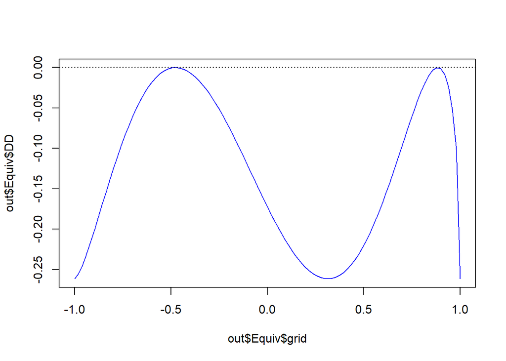

```r
# Draw the equivalence plot
plot(out$Equiv$grid, out$Equiv$DD, type = "l", col = "blue")
abline(h = 0, lty = 3)
```

## Case 2

Statistical packages like STATA and SAS also provide fitting routines using fractional polynomials, suggesting that fractional polynomials are in demand in practice.
Consider, for example, we are interested to find a $E$-optimal design for a fractional polynomial regression model on the interval $[20,80]$, where the variance of the univariate response $y$ is inversely proportional to a known function of the form $\lambda(x)=(x-20)^u(80-x)^v$, where $u, v$ are supposed to be known and different choices of $u$ and $v$ shapes the variance of the response across the design interval. The model is
$$\begin{equation}
E(y) = \theta_0 + \theta_1x^{-2} + \theta_2x^{-1} + \theta_3x^{-0.5} +
\theta_4\log{(x)}
\end{equation}$$

```r
# Set the design requirements
n <- 5                # the number of support points
dSpace <- c(20, 80)    # the design space, c(lower, upper)
pOrder <- c(0, -2, -1, -0.5, -Inf)     # the order of polynomial model terms
# 0: intercept
# Inf: log(x)
# a: x^a, a is numerical value
vParam <- c(1.5, 0.5) # the variance parameters, c(u, v)
```

```r
# Run PSO for Finding E-optimal Design of Heteroscedastic Polynomial Model
out <- genHeterPolyE(nSupp = n, designSpace = dSpace, polyOrder = pOrder,
                     varParam = vParam, designType = "E",
                     eqvData = TRUE, nswarm = 128, maxiter = 100, seed = NULL, verbose = FALSE)
```

```r
# The PSO-generated Design
out$optDesign
```

```
##          dim_1    weight
## obs_1 21.22717 0.2747826
## obs_2 28.44439 0.2243080
## obs_3 43.49141 0.1964704
## obs_4 64.44053 0.1724943
## obs_5 78.96841 0.1319448
```

```r
# The corresponding E-criterion value
# (NEGATIVE of the minimal eignevalue of FIM)
out$CritVal
```

```
## [1] -2.552813e-09
```

```r
# Computing time
out$pso_results$cputime
```

```
## elapsed
##    0.11
```

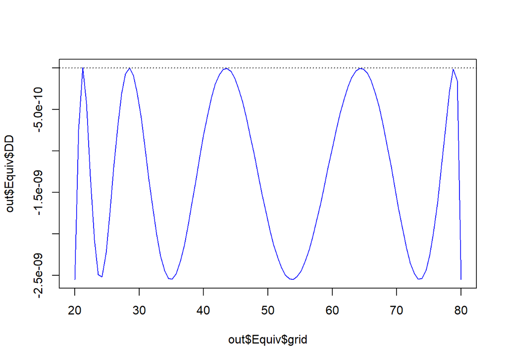

```r
# Draw the equivalence plot
plot(out$Equiv$grid, out$Equiv$DD, type = "l", col = "blue")
abline(h = 0, lty = 3)
```

# Reference

Dette, H. (1993). A note on $E$-optimal designs for weighted polynomial regression. *The Annals of Statistics*, *21*(2), 767–771.